# Optimisation mode

MtM ABM description

Author

David O’Sullivan

Published

October 18, 2025

Modified

May 5, 2026

## Optimisation mode

When the debt service ratio is below 0.25, farmers are in a position to consder changed management practices. They do this following the sequence shown below.

```
flowchart TB
  A((START))
  L[Compile list of<br>possible interventions<br>per holding]
  M[Choose and possibly<br>implement interventions]
  Z((END))
  A --> L
  L --> M
  M --> Z
```

The list of possible interventions is one intervention per holding. The single intervention for each holding is chosen by a random draw among available interventions weighted by the baseline probability of that intervention (drawn from `farmer-threshold-matrix.csv`) ‘nudged’ by a combination of any `nudge` values in the `intervention-details.csv` file, and the fraction of holdings across the farm and the farms of peer group farmers that have already implemented this intervention.

Peer group farmers and nudged probabilities are explained in the sections below.

## Peer group farmers

At model initialisation farmers are assigned a number of ‘neighbours’ locally and across the catchment.

Local neighbours are spatially proximate, while catchment neighbours might be drawn from anywhere across the catchment (i.e., the whole model). The numbers of neighbours are given by the `n-local-links` and `n-catchment-links` model parameters.

It is important to note that each farmer is separately assigned this number of *unique new* links, so that the final number of links in the network will be twice the number implied by this setting. For example, if three local links among 100 farmers were specified then the total number of links in the network will be 300, and each farmer will have on average *six* neighhours, since each link created connects two farmers. Not all farmers will have the same number of links, however.

This is shown below where a relatively low density local link network (`local-links` set to three) is shown, along with a histogram of the node degree distribution. All farmers have at least three links, but a few have as many as 13. Catchment links are not shown here as they form a ‘hairball’ of everywhere-to-everywhere connections.

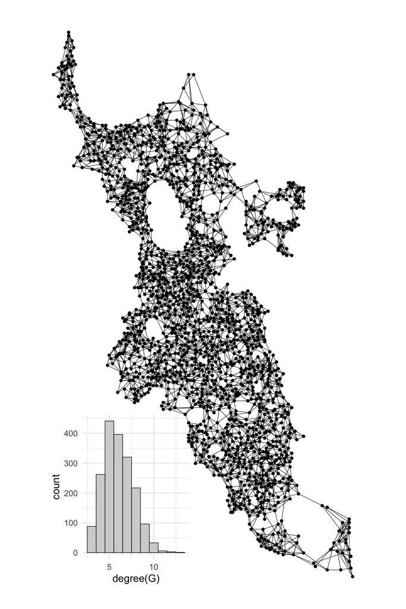

```r
library(pracma)
library(ggplot2)
library(cols4all)
library(tidyr)
library(dplyr)
library(metR)
library(igraph)
library(ggraph)
library(patchwork)

setwd("~/Documents/work/mwlr-moving-the-middle/abm/model-description/documents")
edges <- read.csv("edges.csv")
nodes <- read.csv("farmers.csv") |>
  select(farmer_id, x, y) |>
  rename(name = farmer_id) |>
  relocate(name)

G <- graph_from_data_frame(edges, vertices = nodes, directed = FALSE) |> simplify()

g1 <- ggraph(G, layout = "nicely") +
  geom_edge_link(linewidth = 0.2) +
  geom_node_point(size = 1) +
  coord_equal() +
  theme_void()

g2 <- ggplot(degree(G) |> as.data.frame()) +
  geom_histogram(aes(x = `degree(G)`), binwidth = 1,
                 fill = "lightgrey", colour = "black", linewidth = 0.25) +
  theme_minimal()

g1 + inset_element(g2, 0.025, 0.025, 0.475, 0.325)
```

## Nudge adjustments to probabilities

The ‘nudge’ procedure in the model is an adjustment to a probability based on moving along a sigmoid or ‘S’ curve. The plot below shows how this works at a relatively high efficacy setting of 2. Each curve is labelled with its initial probability, and shows, relative to different degrees of ‘nudging’ on the horizontal axis, what the resulting ‘nudged probability’ is.

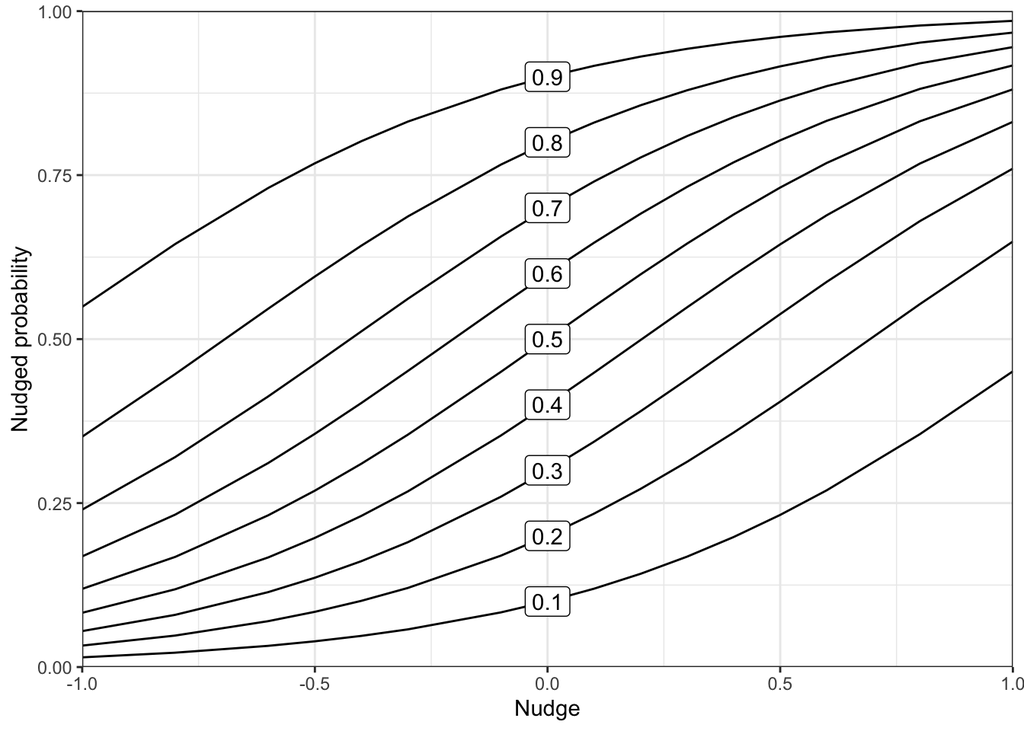

```r
nudge_threshold <- Vectorize(
  function(t, a, nudge) {
    if (t == 0) return (t)
    if (a == 0) return (t)
    c <- logit(t, a = a)
    sigmoid(c + nudge, a = a)
  }
)

df <- expand_grid(
  `Initial probability` = 1:100 / 100,
  Efficacy = 0:50 / 25,
  Nudge = c(-1, -0.8, -0.6, -0.5, -0.4, -0.3,-0.4, -0.1, 0,
                 0.1, 0.2, 0.3, 0.4, 0.5, 0.6, 0.8, 1)) |>
  mutate(`Nudged probability` = nudge_threshold(`Initial probability`, Efficacy, Nudge),
         `Probability multiplier` = `Nudged probability` / `Initial probability`)

ggplot(df |> filter(Efficacy == 2, (`Initial probability` * 10) %% 1 == 0)) +
  geom_line(aes(x = Nudge, y = `Nudged probability`, group = `Initial probability`)) +
  annotate("label", label = 1:9 / 10, x = 0, y = 1:9 / 10) +
  coord_cartesian(xlim = c(-1, 1), ylim = 0:1, expand = FALSE) +
  theme_bw()
```

The summary plot below shows for positive nudges only (which is the case in the model), and different levels of nudge efficacy the resulting outcome probability.

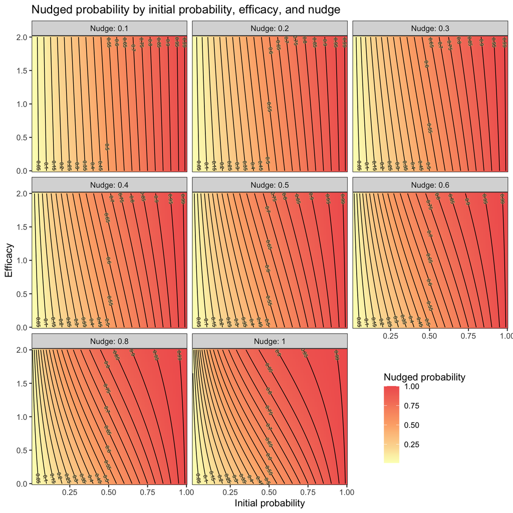

```r
ggplot(data = df |> filter(Nudge > 0),
       aes(x = `Initial probability`, y = Efficacy, z = `Nudged probability`)) +
  geom_tile(aes(fill = `Nudged probability`)) +
  scale_fill_continuous_c4a_seq("-matplotlib.magma", range = 2:3 / 3) +
  geom_contour(breaks = c(0.01, 1:19/20, 0.99), colour = "black", linewidth = 0.35) +
  geom_text_contour(breaks = c(0.01, 1:19/20, 0.99), skip = 0, size = 2, stroke = 0.1, stroke.colour = "#ddcc9940") +
  coord_cartesian(expand = FALSE) +
  facet_wrap( ~ Nudge, labeller = label_both) +
  ggtitle("Nudged probability by initial probability, efficacy, and nudge") +
  theme_bw() +
  theme(legend.position = c(0.825, 0.15))
```

**NoteUpdate History**

| Date | Changes |
| --- | --- |
| 2025-10-18 | Initial post. |
| 2026-05-05 | Added material on link neighbours (peers) and nudge. |